# 12 Analyze your data

#### 12.1.3.4 Step 7: Interpret the results and draw conclusions.

Our last step is to compare our p-value to our $\alpha$ value and draw conclusions. We have filtered our output of the pairwise comparisons to retain only values equal to or lower than our $\alpha$ value but we will still need to interpret our results. Do they indicate that we should accept our null hypothesis or reject it and accept our alternative hypothesis?

**Give it a try**

Compare your p-value to the threshold of significance we defined above to determine how to interpret the results of your statistical test.

Then update the results you formulated earlier to add this information into your description of the results.

**Answer**

To determine whether the differences between treatments are statistically significant, follow these steps:

1. **Identify the p-value**: Each comparison in the table has an associated p-value, which quantifies the probability that the observed difference between treatments occurred by random chance.
2. **Compare to the Significance Threshold**: A common threshold for significance is **α = 0.05** (or 5%). If the **p-value is less than 0.05**, the difference between treatments is considered statistically significant, meaning it is unlikely to have occurred due to chance alone.
3. **Apply Multiple Comparison Corrections**: Since multiple comparisons were made, we use the **Bonferroni correction** and **False Discovery Rate (FDR) adjustment** to account for the increased likelihood of finding a significant result by chance.
   - **Bonferroni correction** is more conservative, adjusting the significance threshold by dividing **α** by the number of comparisons, reducing the chance of false positives.
   - **FDR adjustment** controls the proportion of false positives among significant results, balancing sensitivity and specificity.
4. **Interpret the Results**:
   - If the **raw p-value is below 0.05**, there is strong evidence that the difference between treatments is meaningful but really you should use the adjusted p-values.
   - If the **Bonferroni-adjusted p-value** remains below 0.05, the result is significant, even with strict multiple-testing corrections.
   - If the **FDR-adjusted p-value** is below 0.05 but the Bonferroni-adjusted value is not, the result is likely significant but should be interpreted with some caution.
5. **Update Your Description of Results**: If a treatment comparison is statistically significant, explicitly state this in your results section. If a comparison is **not significant** (p ≥ 0.05 after correction), mention that there is **no strong evidence of a difference** between those treatments.

Here is what your results from above could look like once you have added the results from your statistical tests:

**Emphasize on “Broad Pattern First, Then Details” formula:**

Overall, germination rates varied among deicer treatments, with rock salt having the strongest negative impact, the cheese brine having the least impact, and the commercial blend showing an intermediate effect. The control group had the highest germination rate (92%), indicating baseline germination without deicer exposure.

Among the treatments, rock salt at high concentration had the lowest germination (18%), and statistical comparisons confirmed that this was significantly lower than the control (p < 0.001, Bonferroni and FDR adjusted). The medium (46%) and low (55%) concentrations of rock salt also significantly reduced germination compared to the control (p < 0.001 for medium; and low). Rock salt high was also significantly lower than cheese brine medium (p < 0.001) and low (p < 0.001), as well as the low commercial blend treatment (p < 0.001), suggesting a stronger effect on seed germination than other treatments.

The commercial blend also showed a negative effect, but not as severe as rock salt, with germination increasing from 40% at high concentration to 60% at medium and 83% at low. The highest concentration of commercial blend significantly reduced germination compared to the control (p < 0.001) and was also significantly lower than cheese brine at both medium (p = 0.001) and low (p < 0.001) concentrations.

In contrast, the cheese brine had relatively little impact on germination. Even at the highest concentration, 65% of seeds germinated, which was significantly higher than rock salt high (p < 0.001). The medium (88%) and low (86%) concentrations of cheese brine were not significantly different from the control.

**Emphasis on Highlighting Notable Findings**

The commercial blend also significantly reduced germination, but its effects were not as strong as rock salt. The highest concentration resulted in 40% germination, which was significantly lower than the control (p < 0.001) and lower than cheese brine medium (p = 0.001) and cheese brine low (p < 0.001). However, germination in the commercial blend low treatment (83%) was not significantly different from the control.

Interestingly, the cheese brine had the least effect, with germination at its highest concentration (65%) still significantly higher than rock salt at the same level (p < 0.001). Medium and low concentrations of cheese brine (88% and 86%) were nearly identical to the control and not significantly different, indicating minimal impact.

**Emphasis on Highlighting Patterns with Comparative Terms**

The commercial blend also reduced germination, but its effects were less severe than rock salt, with the highest concentration (40%) showing significantly lower germination than the control (p < 0.0001) and also significantly lower than cheese brine medium (p = 0.001) and low (p < 0.001). However, germination in the low commercial blend treatment (83%) was not significantly different from the control.

## 12.2 Seedling length

### 12.2.1 Get your data

Go to the `GoogleSheet` that contains the seedling lengths for your lab and select the tab for your group. Double check that the data has been entered correctly. Then go to `File` -> `Download` -> `Tab Separated Values (.tsv)` down load your data as a tab-delimited file. Now, use your `File Explorer` if you are on a Windows computer and `Finder` of you are on a Mac and navigate to the `Downloads` folder. You should see the file you just downloaded there. Rename it to `seedling-length_plant.tsv` depending on the plant you are testing and place it in the `data` folder of your `02_Allelopathy` project folder.

Once you go back to your `Rstudio` window with your `Rproj` loaded you should see the file in your `data` folder in the `Files` pane. Double check that it is there, if not, as you instructor to help you get set up.

Now we are ready to read in our seedling length data as a `data.frame` that we can compute on in `R`.

```r
# read in data
length_ex <- read_delim(here("data", "seedling_length-1.csv"), delim = ",") |>
  clean_names() |>
  unite(treatment, deicer, treatment_level,
        sep = "_", remove = FALSE) |>
  mutate(treatment_level = factor(treatment_level,
                                  levels = c("high", "medium", "low", "trace")))

# read in data
length_A <- read_delim(here("data", "seedlings_Section-A.csv"), delim = ",") |>
  clean_names() |>
  unite(treatment, deicer, treatment_level,
        sep = "_", remove = FALSE) |>
  mutate(treatment_level = factor(treatment_level,
                                  levels = c("high", "medium", "low", "trace")))

# read in data
length_B <- read_delim(here("data", "seedlings_Section-B.csv"), delim = ",") |>
  clean_names() |>
  unite(treatment, deicer, treatment_level,
        sep = "_", remove = FALSE) |>
  mutate(treatment_level = factor(treatment_level,
                                  levels = c("high", "medium", "low", "trace")))

# take a look at first few lines
head(length)
```

```
1 .Primitive("length")
```

Let’s take a quick look at the sample sizes and completeness of our data sets. Remember that we are only using data on the seedlings of germinated seeds so our sample sizes should be a lot more variable. This is also why we used a sample size of 60 over three replicates so that even if we had strong inhibition that would still give us a sufficient sample size.

```r
# Example data set
length_ex %>%
  group_by(deicer) %>%
  count() %>%
  kable()
```

| deicer | n |
| --- | --- |
| cheese_brine | 145 |
| comm_blend | 131 |
| control | 60 |
| rock_salt | 104 |

```r
length_ex %>%
  group_by(deicer, treatment_level, replicate) %>%
  count() %>%
  kable()
```

| deicer | treatment_level | replicate | n |
| --- | --- | --- | --- |
| cheese_brine | high | 1 | 10 |
| cheese_brine | high | 2 | 11 |
| cheese_brine | high | 3 | 4 |
| cheese_brine | medium | 1 | 20 |
| cheese_brine | medium | 2 | 20 |
| cheese_brine | medium | 3 | 20 |
| cheese_brine | low | 1 | 20 |
| cheese_brine | low | 2 | 20 |
| cheese_brine | low | 3 | 20 |
| comm_blend | high | 1 | 10 |
| comm_blend | high | 2 | 12 |
| comm_blend | high | 3 | 8 |
| comm_blend | medium | 1 | 12 |
| comm_blend | medium | 2 | 16 |
| comm_blend | medium | 3 | 13 |
| comm_blend | low | 1 | 20 |
| comm_blend | low | 2 | 20 |
| comm_blend | low | 3 | 20 |
| control | NA | 1 | 20 |
| control | NA | 2 | 20 |
| control | NA | 3 | 20 |
| rock_salt | high | 1 | 5 |
| rock_salt | high | 2 | 5 |
| rock_salt | high | 3 | 3 |
| rock_salt | medium | 1 | 10 |
| rock_salt | medium | 2 | 11 |
| rock_salt | medium | 3 | 10 |
| rock_salt | low | 1 | 20 |
| rock_salt | low | 2 | 20 |
| rock_salt | low | 3 | 20 |

```r
length_ex %>%
  group_by(deicer, treatment_level) %>%
  count() %>%
  kable()
```

| deicer | treatment_level | n |
| --- | --- | --- |
| cheese_brine | high | 25 |
| cheese_brine | medium | 60 |
| cheese_brine | low | 60 |
| comm_blend | high | 30 |
| comm_blend | medium | 41 |
| comm_blend | low | 60 |
| control | NA | 60 |
| rock_salt | high | 13 |
| rock_salt | medium | 31 |
| rock_salt | low | 60 |

**Give it a try**

Modify the code above to produce the same summary tables for your data set.

**Answer**

For section A

```r
# Section A data set
length_A %>%
  group_by(deicer) %>%
  count() %>%
  kable()
```

| deicer | n |
| --- | --- |
| Fusion2330 | 238 |
| NaCl | 238 |
| control | 59 |

```r
length_A %>%
  group_by(deicer, treatment_level, replicate) %>%
  count() %>%
  kable()
```

| deicer | treatment_level | replicate | n |
| --- | --- | --- | --- |
| Fusion2330 | high | 1 | 20 |
| Fusion2330 | high | 2 | 20 |
| Fusion2330 | high | 3 | 20 |
| Fusion2330 | medium | 1 | 20 |
| Fusion2330 | medium | 2 | 19 |
| Fusion2330 | medium | 3 | 19 |
| Fusion2330 | low | 1 | 20 |
| Fusion2330 | low | 2 | 20 |
| Fusion2330 | low | 3 | 20 |
| Fusion2330 | trace | 1 | 20 |
| Fusion2330 | trace | 2 | 20 |
| Fusion2330 | trace | 3 | 20 |
| NaCl | high | 1 | 19 |
| NaCl | high | 2 | 20 |
| NaCl | high | 3 | 20 |
| NaCl | medium | 1 | 20 |
| NaCl | medium | 2 | 20 |
| NaCl | medium | 3 | 20 |
| NaCl | low | 1 | 19 |
| NaCl | low | 2 | 20 |
| NaCl | low | 3 | 20 |
| NaCl | trace | 1 | 20 |
| NaCl | trace | 2 | 20 |
| NaCl | trace | 3 | 20 |
| control | NA | 1 | 20 |
| control | NA | 2 | 20 |
| control | NA | 3 | 19 |

```r
length_A %>%
  group_by(deicer, treatment_level) %>%
  count() %>%
  kable()
```

| deicer | treatment_level | n |
| --- | --- | --- |
| Fusion2330 | high | 60 |
| Fusion2330 | medium | 58 |
| Fusion2330 | low | 60 |
| Fusion2330 | trace | 60 |
| NaCl | high | 59 |
| NaCl | medium | 60 |
| NaCl | low | 59 |
| NaCl | trace | 60 |
| control | NA | 59 |

For section B

```r
# Section B data set
length_B %>%
  group_by(deicer) %>%
  count() %>%
  kable()
```

| deicer | n |
| --- | --- |
| CaCl | 119 |
| DI-water | 60 |
| MgCl | 117 |
| NaCl | 59 |
| Tap-water | 59 |
| beet | 119 |
| urea | 120 |

```r
length_B %>%
  group_by(deicer, treatment_level, replicate) %>%
  count() %>%
  kable()
```

| deicer | treatment_level | replicate | n |
| --- | --- | --- | --- |
| CaCl | high | 1 | 39 |
| CaCl | high | 3 | 20 |
| CaCl | low | 1 | 40 |
| CaCl | low | 3 | 20 |
| DI-water | NA | 1 | 20 |
| DI-water | NA | 2 | 20 |
| DI-water | NA | 3 | 20 |
| MgCl | high | 1 | 20 |
| MgCl | high | 2 | 20 |
| MgCl | high | 3 | 18 |
| MgCl | low | 1 | 19 |
| MgCl | low | 2 | 20 |
| MgCl | low | 3 | 20 |
| NaCl | high | 1 | 19 |
| NaCl | high | 2 | 20 |
| NaCl | high | 3 | 20 |
| Tap-water | NA | 1 | 20 |
| Tap-water | NA | 2 | 20 |
| Tap-water | NA | 3 | 19 |
| beet | high | 1 | 20 |
| beet | high | 2 | 20 |
| beet | high | 3 | 19 |
| beet | low | 1 | 20 |
| beet | low | 2 | 20 |
| beet | low | 3 | 20 |
| urea | high | 1 | 20 |
| urea | high | 2 | 20 |
| urea | high | 3 | 20 |
| urea | low | 1 | 20 |
| urea | low | 2 | 20 |
| urea | low | 3 | 20 |

```r
length_B %>%
  group_by(deicer, treatment_level) %>%
  count() %>%
  kable()
```

| deicer | treatment_level | n |
| --- | --- | --- |
| CaCl | high | 59 |
| CaCl | low | 60 |
| DI-water | NA | 60 |
| MgCl | high | 58 |
| MgCl | low | 59 |
| NaCl | high | 59 |
| Tap-water | NA | 59 |
| beet | high | 59 |
| beet | low | 60 |
| urea | high | 60 |
| urea | low | 60 |

There seems to be a mislabeling issue with the CaCl petri dishes but since we are going to combine replicates we can leave it for now.

### 12.2.2 Summarize your results

**Consider this**

Take a look at the `data.frame` object holding your data by clicking on it in the `Environment` pane (bottom left) or using `View(object)`.

Describe how your data is organized:

- what information is in each row?
- what information is in each column?

Assess what type of data you have

- is it continuous or categorical?
- what groups are you comparing?

Then determine which descriptive statistics are appropriate to summarize this data set and how you would visualize your data.

**Answer**

Each row represents one seedling. And each column contains information for one variable.

Your data is continuous; you have a length measurement in millimeters. You have various treatments which you are comparing which are a combination of the deicer type and the concentration level. This is a categorical variable.

You will want to determine the mean and standard deviation of the seedling length for both treatments. It could also be helpful to generate additional summary statistics including median, minimum and maximum values to give yourself an overview of the data.

We can use various visualizations for your data set, the first is that you can visualize the distributions using a histogram or boxplot, the second is that you can visualize the mean and standard deviation using a bar chart or similar.

We will need to summarize our results to evaluate our findings.

**Consider this**

Suggest 3-4 metrics to summarize your data in a meaningful way that will allow you to describe your results in the context of the hypothesis you are exploring with this experiment.

Explain why you think these would be appropriate data analysis methods.

**Answer**

As we have continuous data, we can use the descriptive statistics that allow us to assess the distribution (histogram), central tendency (mean, median, mode) and variability (variance, standard deviation, range) of our data.

Let’s start by putting together a table with summary statistics.

```r
# calculate summary stats for deicer and treatment_level
summary <- length_ex |>                              # specify object
  group_by(deicer, treatment_level) |>            # group by treatment
  summarize(mean = mean(length_mm),
            sd = sd(length_mm),
            min = sd(length_mm),
            max = max(length_mm),
            median = median(length_mm))  # calculate summary stats

# print table
summary |>
  kable(digits = 1)
```

| deicer | treatment_level | mean | sd | min | max | median |
| --- | --- | --- | --- | --- | --- | --- |
| cheese_brine | high | 7.6 | 3.5 | 3.5 | 12.5 | 8.7 |
| cheese_brine | medium | 10.4 | 2.8 | 2.8 | 16.8 | 10.8 |
| cheese_brine | low | 10.5 | 2.3 | 2.3 | 14.7 | 10.4 |
| comm_blend | high | 3.7 | 1.7 | 1.7 | 6.8 | 3.5 |
| comm_blend | medium | 8.4 | 2.6 | 2.6 | 16.0 | 8.1 |
| comm_blend | low | 10.6 | 2.0 | 2.0 | 16.0 | 10.6 |
| control | NA | 11.2 | 2.6 | 2.6 | 17.8 | 11.5 |
| rock_salt | high | 4.0 | 1.6 | 1.6 | 6.1 | 3.5 |
| rock_salt | medium | 6.4 | 1.7 | 1.7 | 10.7 | 6.3 |
| rock_salt | low | 10.5 | 2.4 | 2.4 | 16.2 | 10.6 |

**Give it a try**

Modify the code above to calculate additional summary statistics for your data set.

**Answer**

Section A data set

```r
# calculate summary stats for deicer and treatment_level
summary <- length_A |>                      # specify object
  group_by(deicer, treatment_level) |>      # group by treatment
  summarize(mean = mean(length_mm),
            sd = sd(length_mm),
            min = sd(length_mm),
            max = max(length_mm),
            median = median(length_mm))     # calculate summary stats

# print table
summary |>
  kable(digits = 1)
```

| deicer | treatment_level | mean | sd | min | max | median |
| --- | --- | --- | --- | --- | --- | --- |
| Fusion2330 | high | 46.1 | 22.1 | 22.1 | 85 | 48.0 |
| Fusion2330 | medium | 52.7 | 17.6 | 17.6 | 93 | 54.0 |
| Fusion2330 | low | 59.6 | 22.2 | 22.2 | 111 | 63.0 |
| Fusion2330 | trace | 52.9 | 25.6 | 25.6 | 105 | 48.0 |
| NaCl | high | 15.2 | 8.2 | 8.2 | 43 | 13.0 |
| NaCl | medium | 46.9 | 25.0 | 25.0 | 89 | 53.5 |
| NaCl | low | 49.1 | 19.0 | 19.0 | 99 | 54.0 |
| NaCl | trace | 66.0 | 24.8 | 24.8 | 144 | 65.0 |
| control | NA | 52.8 | 21.5 | 21.5 | 105 | 55.0 |

Section B data set

```r
# calculate summary stats for deicer and treatment_level
summary <- length_B |>                      # specify object
  group_by(deicer, treatment_level) |>      # group by treatment
  summarize(mean = mean(length_mm),
            sd = sd(length_mm),
            min = sd(length_mm),
            max = max(length_mm),
            median = median(length_mm))     # calculate summary stats

# print table
summary |>
  kable(digits = 1)
```

| deicer | treatment_level | mean | sd | min | max | median |
| --- | --- | --- | --- | --- | --- | --- |
| CaCl | high | 13.1 | 10.8 | 10.8 | 49 | 10.0 |
| CaCl | low | 12.3 | 6.8 | 6.8 | 30 | 10.0 |
| DI-water | NA | 46.4 | 15.8 | 15.8 | 75 | 48.5 |
| MgCl | high | 13.7 | 5.1 | 5.1 | 25 | 13.0 |
| MgCl | low | 13.2 | 5.6 | 5.6 | 35 | 13.0 |
| NaCl | high | 15.2 | 8.2 | 8.2 | 43 | 13.0 |
| Tap-water | NA | 43.1 | 18.8 | 18.8 | 81 | 45.0 |
| beet | high | 50.9 | 21.3 | 21.3 | 86 | 53.0 |
| beet | low | 47.3 | 15.1 | 15.1 | 85 | 46.5 |
| urea | high | 33.2 | 15.3 | 15.3 | 64 | 30.0 |
| urea | low | 40.1 | 15.5 | 15.5 | 77 | 40.5 |

Again, data visualizations are an important tool to summarize and present your data. Let’s start by visualizing our data with a box plot which emphasize the distribution of our values.

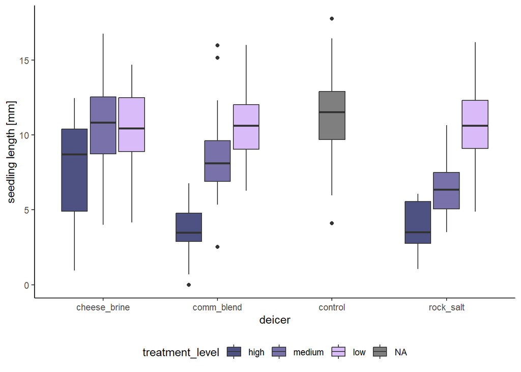

Figure 12.4: Seedling length distribution after 1 week for radish seeds explosed to various deicers for different concentrations.

```r
# make box plots
ggplot(length_ex,                                   # specify object to plot
       aes(x = deicer,                              # column on x-axis
           y = length_mm,                           # column on y-axis
           fill = treatment_level)) +              # column to group by
  geom_boxplot(position = position_dodge2(preserve = "single")) + # plot type
  scale_fill_manual(values = c("#4E5283",
                               "#7871AA",
                               "#D9BBF9",
                               "#AA9FB1")) +         # modify for custom colors
  labs(x = "deicer",                                 # x-axis title
      y = "seedling length [mm]") +                  # y-axis title
  theme_classic() +                                  # specify theme
  theme(legend.position = "bottom")                  # legend position
```

A **boxplot** or box-and-whisker plot is a graphical summary of a dataset that helps visualize its distribution, variability, and potential outliers. Boxplots are useful for comparing distributions across different groups, making them a powerful tool for visualizing overall patterns in data. A shorter box means less variability, while a longer box indicates more spread in the middle 50% of the data. If the median is centered in the box, the data is symmetrical; if it’s closer to one side, the data is skewed. Outliers suggest unusual values that may need further investigation.

Here’s how to interpret it:

1. **Box (Interquartile Range, IQR):** The box represents the middle 50% of the data (the interquartile range, or IQR), spanning from the first quartile (Q1, 25th percentile) to the third quartile (Q3, 75th percentile). The line inside the box marks the median (Q2, 50th percentile)—the middle value of the dataset.
2. **Whiskers (Data Spread):** The whiskers extend to the smallest and largest values within a reasonable range (typically 1.5 × IQR from Q1 and Q3). If whiskers are longer on one side, it suggests skewness (asymmetry in the data distribution).
3. **Outliers (Unusual Data Points):** Dots or asterisks outside the whiskers indicate potential outliers, meaning values that are unusually high or low compared to the rest of the data.

**Give it a try**

Modify the code to produce box plots for your own data set.

**Answer**

Section A data set

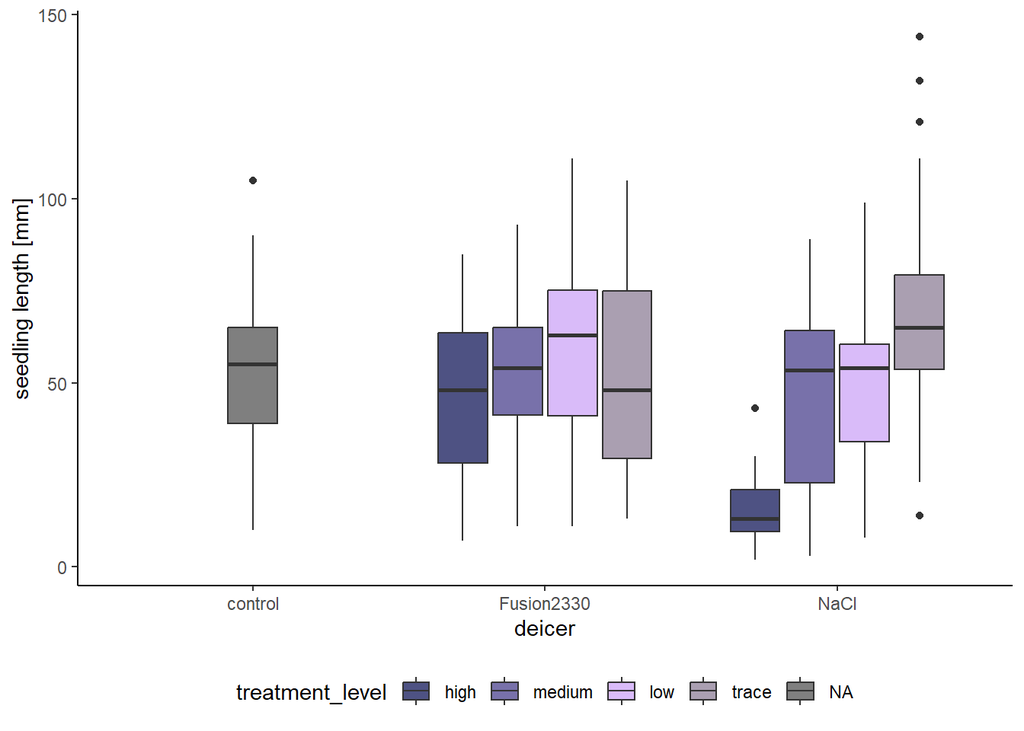

```r
# make box plots
ggplot(length_A,                                   # specify object to plot
       aes(x = deicer,                              # column on x-axis
           y = length_mm,                           # column on y-axis
           fill = treatment_level)) +              # column to group by
  geom_boxplot(position = position_dodge2(preserve = "single")) + # plot type
  scale_fill_manual(values = c("#4E5283",
                               "#7871AA",
                               "#D9BBF9",
                               "#AA9FB1")) +         # modify for custom colors
  labs(x = "deicer",                                 # x-axis title
      y = "seedling length [mm]") +                  # y-axis title
  theme_classic() +                                  # specify theme
  theme(legend.position = "bottom")                  # legend position
```

Section B data set

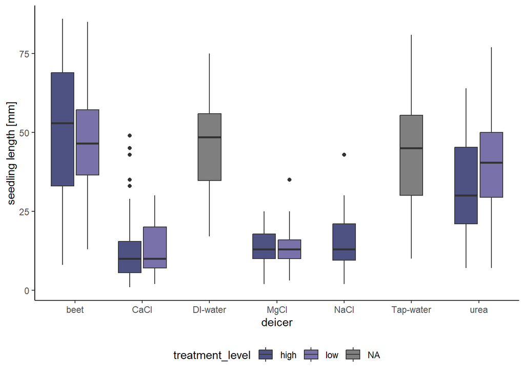

```r
# make box plots
ggplot(length_B,                                   # specify object to plot
       aes(x = deicer,                              # column on x-axis
           y = length_mm,                           # column on y-axis
           fill = treatment_level)) +              # column to group by
  geom_boxplot(position = position_dodge2(preserve = "single")) + # plot type
  scale_fill_manual(values = c("#4E5283",
                               "#7871AA",
                               "#D9BBF9",
                               "#AA9FB1")) +         # modify for custom colors
  labs(x = "deicer",                                 # x-axis title
      y = "seedling length [mm]") +                  # y-axis title
  theme_classic() +                                  # specify theme
  theme(legend.position = "bottom")                  # legend position
```

Alternatively, we could create a bar plot where the height is scaled relative to the mean. This also allows us to add error bars that are scaled to the length of the standard deviation[^4]. Bar plots take up a lot of “ink” and so an alternative is to create a plot using a point range. In that case the mean is represented by a point and the standard deviation by lines extending out from that point.

<sup>4</sup> This is a classic plot for experiments with multiple treatments

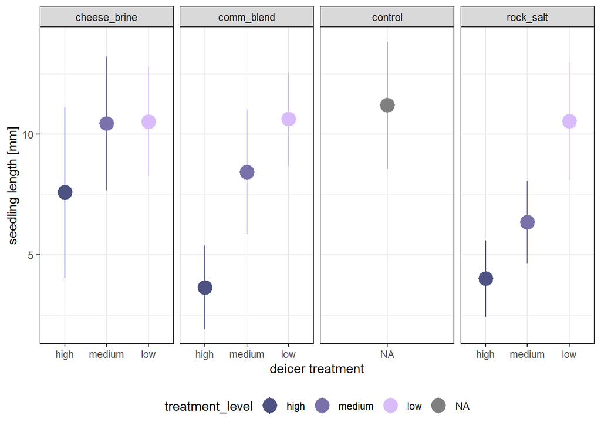

Figure 12.5: Mean seedling length and standard deviation after 1 week for radish seeds explosed to deicers at various treatment levels.

```r
# plot mean and standard deviation
summary <- length_ex %>%
  group_by(deicer, treatment_level) %>%
  summarise(mean = mean(length_mm),
            sd = sd(length_mm))

ggplot(summary) +
  geom_pointrange(aes(x = treatment_level,
                      y = mean,
                      ymin = mean-sd,
                      ymax = mean+sd,
                      color = treatment_level),
                  size = 1.2) +
  facet_grid(. ~ deicer, scales = "free_x") +
  scale_color_manual(values = c("#4E5283",
                               "#7871AA",
                               "#D9BBF9",
                               "#AA9FB1")) +
  labs(x = "deicer treatment",
       y = "seedling length [mm]") +
  theme_bw() +
  theme(legend.position = "bottom")
```

**Give it a try**

Modify the code above to produce a plot for your data set.

**Answer**

Section A

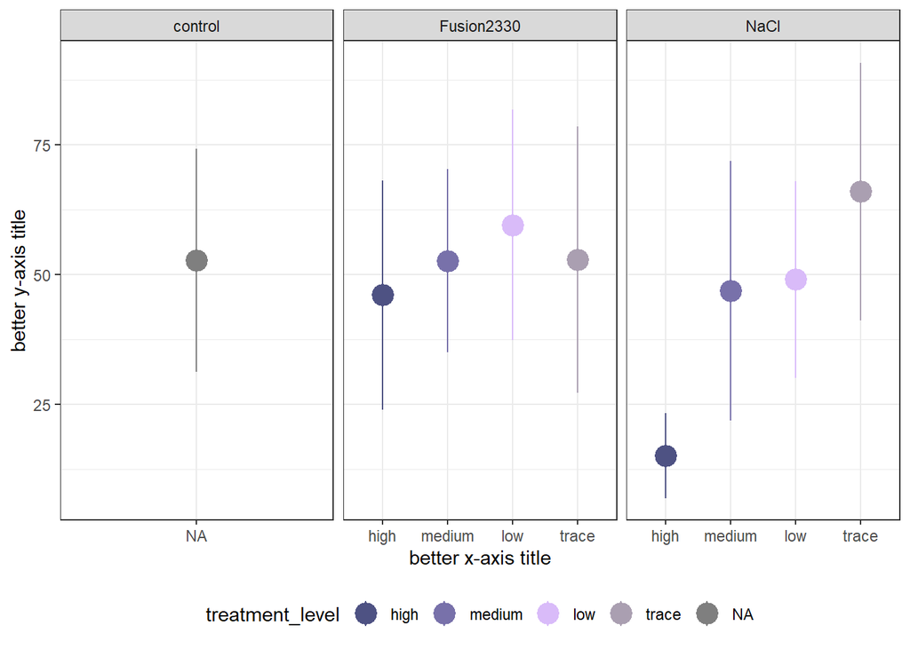

```r
# plot mean and standard deviation
summary <- length_A %>%
  group_by(deicer, treatment_level) %>%
  summarise(mean = mean(length_mm),
            sd = sd(length_mm))

ggplot(summary) +
  geom_pointrange(aes(x = treatment_level,
                      y = mean,
                      ymin = mean-sd,
                      ymax = mean+sd,
                      color = treatment_level),
                  size = 1.2) +
  facet_grid(. ~ deicer, scales = "free_x") +
  scale_color_manual(values = c("#4E5283",
                               "#7871AA",
                               "#D9BBF9",
                               "#AA9FB1")) +
  labs(x = "better x-axis title",
       y = "better y-axis title") +
  theme_bw() +
  theme(legend.position = "bottom")
```

Section B

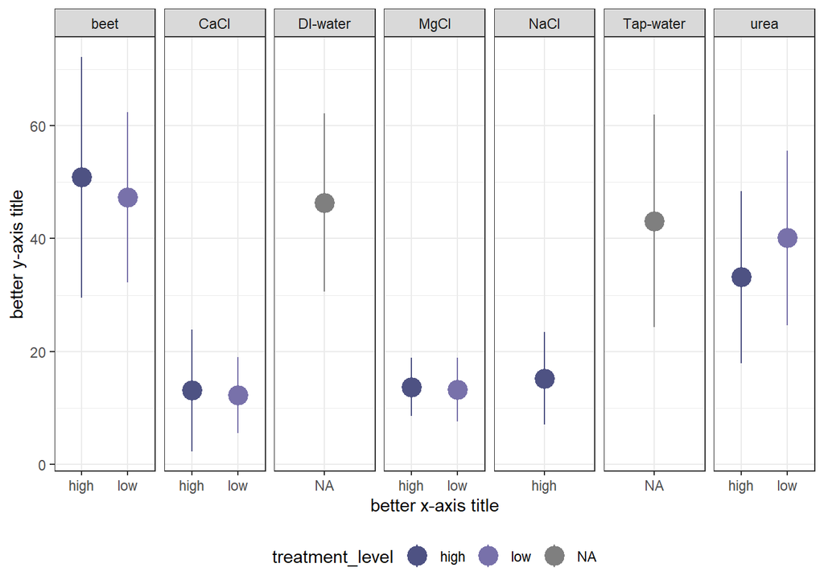

```r
# plot mean and standard deviation
summary <- length_B %>%
  group_by(deicer, treatment_level) %>%
  summarise(mean = mean(length_mm),
            sd = sd(length_mm))

ggplot(summary) +
  geom_pointrange(aes(x = treatment_level,
                      y = mean,
                      ymin = mean-sd,
                      ymax = mean+sd,
                      color = treatment_level),
                  size = 1.2) +
  facet_grid(. ~ deicer, scales = "free_x") +
  scale_color_manual(values = c("#4E5283",
                               "#7871AA",
                               "#D9BBF9",
                               "#AA9FB1")) +
  labs(x = "better x-axis title",
       y = "better y-axis title") +
  theme_bw() +
  theme(legend.position = "bottom")
```

**Give it a try**

Describe your results. Make sure that you are being specific and adding context to make it easy for your reader to identify the key patterns. Consider this thinking out loud in a way where you have a set of notes that you can then edit for your report.

As rule of thumb, you should describe your results so that your reader has all the key information they need even without seeing the data tables. Make sure that you describe broad patterns before you report notable highlights. As you work through your description, interpretation, and discussion you may need to come back to your original description and revise it because you’ll have a better idea of what your discussion will look like and which highlights you want to mention here so that you can pick up on them again at a later point.

Remember, at this point you should not be interpreting your results!

**Answer**

Your description could look something like this:

Broad pattern:

> Overall, seedling growth was lower for radish seeds exposed to deicer X compared to the control.

Details

> Mean seedling growth after 1 week was xx +/- xx mm for plants exposed to deicer X compared to a mean length of yyy +/- yy mm in the control. Similarly, the variability in seedling length was higher in exposed radish seeds (range = zz -zz mm) compared to the control (range = zz- zz mm).

In this case, you would not need to include table because you’ve included all the values, rather you might chose to include figure that effectively summarizes your data that you would then reference here.

Again, our set of summary statistics and data visualization enable us to present the patterns in our data set. However, at this point we cannot make statement whether our observed differences in seedling lengths are within the range of variability in growth we would expect to see even if the deicer does not have an effect on growth.

### 12.2.3 Test for significance

For a pairwise comparison between two means we would apply a $t$-test to evaluate the difference between means. However in this case we have multiple treatments that we want to compare and so we would use an ANOVA (analysis of variance). Similar to our germination data that will only tell us if there is significant variance in the data set overall and we will need to follow this with pairwise comparisons.

#### 12.2.3.1 Step 3: State your your null and alternate hypothesis and predict the outcome assuming the null hypothesis is true.

**Give it a try**

State your null and alternative hypothesis and predict the outcome if each claim is true.

**Answer**

Your null hypothesis is a claim that there is no effect:

- $H_{0}$: Presence of deicers does not have an effect on the growth rate of radish seeds.
- Prediction: The seedling length does not differ between the experimental treatments.

The alternative hypothesis is a claim that there is an observed effect.

- $H_{0}$: Presence of deicers has a negative effect on the growth rate of radish seeds.
- Prediction: The seedling length for seeds exposed to plant X will be lower compared to the control.

#### 12.2.3.2 Step 4: Specify a significance threshold.

**Consider this**

We will specify our significance threshold $\alpha$ as 0.05.

Explain what this means and why it is important for us to specify this.

**Answer**

This means that if our observed results have a less than 5% probability occurring according to our null distribution we will reject our null hypothesis.

#### 12.2.3.3 Step 5: Calculate your test statistic and generate sampling distribution and Step 6: Get your p-value.

Let’s perform the analysis of variance. To do this we need to specify the columns containing dependent variable and the independent variable using a “formula notation” (column names separated by a `~` ) as well as the object containing our data.

```r
# Perform ANOVA
anova_ex <- aov(length_mm ~ treatment, data = length_ex)

# View summary of ANOVA results
summary(anova_ex)
```

```
             Df Sum Sq Mean Sq F value Pr(>F)
treatment     9   2269  252.13   43.24 <2e-16 ***
Residuals   430   2507    5.83
---
Signif. codes:  0 '***' 0.001 '**' 0.01 '*' 0.05 '.' 0.1 ' ' 1
```

**Interpreting the ANOVA Output**

- **“Df” (Degrees of Freedom):** Shows how many groups and observations are in the analysis.
- **“Sum Sq” (Sum of Squares):** Measures total variation in the data.
- **“Mean Sq” (Mean Square):** Sum of squares divided by degrees of freedom.
- **“F value”:** The test statistic; higher values indicate greater differences between groups.
- **“Pr(>F)” (p-value):** If **p < 0.05**, we reject the null hypothesis and conclude that at least one treatment level has a significantly different mean.

**Give it a try**

Modify the code above to perform an ANOVA on your data set.

**Answer**

Section A:

```r
# Perform ANOVA
anova_A <- aov(length_mm ~ treatment, data = length_A)

# View summary of ANOVA results
summary(anova_A)
```

```
             Df Sum Sq Mean Sq F value Pr(>F)
treatment     8  94773   11847   26.09 <2e-16 ***
Residuals   526 238859     454
---
Signif. codes:  0 '***' 0.001 '**' 0.01 '*' 0.05 '.' 0.1 ' ' 1
```

Section B:

```r
# Perform ANOVA
anova_B <- aov(length_mm ~ treatment, data = length_B)

# View summary of ANOVA results
summary(anova_B)
```

```
             Df Sum Sq Mean Sq F value Pr(>F)
treatment    10 157334   15733   84.49 <2e-16 ***
Residuals   642 119550     186
---
Signif. codes:  0 '***' 0.001 '**' 0.01 '*' 0.05 '.' 0.1 ' ' 1
```

As our p-values are below the specified threshold level of 0.05 we now know that at least one treatment has a significantly different mean. Next, we will perform post-hoc Tukey tests so that we can determine which pairwise comparisons are significant. If a pairwise comparison has **p < 0.05**, those two treatment levels have a statistically significant difference in seedling length. This approach allows us to determine whether deicer type and treatment level influences seedling length and, if so, which specific treatments cause the differences.

Again we will then filter our output so that we have a much smaller table that only shows pairs that are significantly different.

```r
# Post-hoc test to compare treatment levels
tukey_df <- tidy(TukeyHSD(anova_ex))

# look at first few rows
tukey_df %>%
  head() %>%
  kable()
```

| term | contrast | null.value | estimate | conf.low | conf.high | adj.p.value |
| --- | --- | --- | --- | --- | --- | --- |
| treatment | cheese_brine_low-cheese_brine_high | 0 | 2.9186667 | 1.090479 | 4.746855 | 0.0000250 |
| treatment | cheese_brine_medium-cheese_brine_high | 0 | 2.8376667 | 1.009479 | 4.665855 | 0.0000497 |
| treatment | comm_blend_high-cheese_brine_high | 0 | -3.9396667 | -6.019400 | -1.859933 | 0.0000002 |
| treatment | comm_blend_low-cheese_brine_high | 0 | 3.0203333 | 1.192145 | 4.848521 | 0.0000103 |
| treatment | comm_blend_medium-cheese_brine_high | 0 | 0.8312195 | -1.117580 | 2.780019 | 0.9394135 |
| treatment | control_NA-cheese_brine_high | 0 | 3.5996667 | 1.771479 | 5.427855 | 0.0000000 |

```r
# print table with significant pairwise comparisons
tukey_df %>%
  filter(adj.p.value <= 0.05) %>%
  kable()
```

| term | contrast | null.value | estimate | conf.low | conf.high | adj.p.value |
| --- | --- | --- | --- | --- | --- | --- |
| treatment | cheese_brine_low-cheese_brine_high | 0 | 2.918667 | 1.0904786 | 4.7468547 | 0.0000250 |
| treatment | cheese_brine_medium-cheese_brine_high | 0 | 2.837667 | 1.0094786 | 4.6658547 | 0.0000497 |
| treatment | comm_blend_high-cheese_brine_high | 0 | -3.939667 | -6.0194004 | -1.8599329 | 0.0000002 |
| treatment | comm_blend_low-cheese_brine_high | 0 | 3.020333 | 1.1921453 | 4.8485214 | 0.0000103 |
| treatment | control_NA-cheese_brine_high | 0 | 3.599667 | 1.7714786 | 5.4278547 | 0.0000000 |
| treatment | rock_salt_high-cheese_brine_high | 0 | -3.585385 | -6.2114598 | -0.9593095 | 0.0007334 |
| treatment | rock_salt_low-cheese_brine_high | 0 | 2.944667 | 1.1164786 | 4.7728547 | 0.0000200 |
| treatment | comm_blend_high-cheese_brine_low | 0 | -6.858333 | -8.5756170 | -5.1410497 | 0.0000000 |
| treatment | comm_blend_medium-cheese_brine_low | 0 | -2.087447 | -3.6435925 | -0.5313018 | 0.0010100 |
| treatment | rock_salt_high-cheese_brine_low | 0 | -6.504051 | -8.8535281 | -4.1545745 | 0.0000000 |
| treatment | rock_salt_medium-cheese_brine_low | 0 | -4.158022 | -5.8567394 | -2.4593036 | 0.0000000 |
| treatment | comm_blend_high-cheese_brine_medium | 0 | -6.777333 | -8.4946170 | -5.0600497 | 0.0000000 |
| treatment | comm_blend_medium-cheese_brine_medium | 0 | -2.006447 | -3.5625925 | -0.4503018 | 0.0019891 |
| treatment | rock_salt_high-cheese_brine_medium | 0 | -6.423051 | -8.7725281 | -4.0735745 | 0.0000000 |
| treatment | rock_salt_medium-cheese_brine_medium | 0 | -4.077021 | -5.7757394 | -2.3783036 | 0.0000000 |
| treatment | comm_blend_low-comm_blend_high | 0 | 6.960000 | 5.2427164 | 8.6772836 | 0.0000000 |
| treatment | comm_blend_medium-comm_blend_high | 0 | 4.770886 | 2.9257278 | 6.6160446 | 0.0000000 |
| treatment | control_NA-comm_blend_high | 0 | 7.539333 | 5.8220497 | 9.2566170 | 0.0000000 |
| treatment | rock_salt_low-comm_blend_high | 0 | 6.884333 | 5.1670497 | 8.6016170 | 0.0000000 |
| treatment | rock_salt_medium-comm_blend_high | 0 | 2.700312 | 0.7334200 | 4.6672037 | 0.0006617 |
| treatment | comm_blend_medium-comm_blend_low | 0 | -2.189114 | -3.7452592 | -0.6329684 | 0.0004152 |
| treatment | rock_salt_high-comm_blend_low | 0 | -6.605718 | -8.9551947 | -4.2562411 | 0.0000000 |
| treatment | rock_salt_medium-comm_blend_low | 0 | -4.259688 | -5.9584060 | -2.5609703 | 0.0000000 |
| treatment | control_NA-comm_blend_medium | 0 | 2.768447 | 1.2123018 | 4.3245925 | 0.0000012 |
| treatment | rock_salt_high-comm_blend_medium | 0 | -4.416604 | -6.8611056 | -1.9721026 | 0.0000008 |
| treatment | rock_salt_low-comm_blend_medium | 0 | 2.113447 | 0.5573018 | 3.6695925 | 0.0008079 |
| treatment | rock_salt_medium-comm_blend_medium | 0 | -2.070574 | -3.8984662 | -0.2426825 | 0.0128487 |
| treatment | rock_salt_high-control_NA | 0 | -7.185051 | -9.5345281 | -4.8355745 | 0.0000000 |
| treatment | rock_salt_medium-control_NA | 0 | -4.839022 | -6.5377394 | -3.1403036 | 0.0000000 |
| treatment | rock_salt_low-rock_salt_high | 0 | 6.530051 | 4.1805745 | 8.8795281 | 0.0000000 |
| treatment | rock_salt_medium-rock_salt_low | 0 | -4.184022 | -5.8827394 | -2.4853036 | 0.0000000 |

```r
# print table with pairwise comparisons that are not significantly different
tukey_df %>%
  filter(adj.p.value >= 0.05) %>%
  kable()
```

| term | contrast | null.value | estimate | conf.low | conf.high | adj.p.value |
| --- | --- | --- | --- | --- | --- | --- |
| treatment | comm_blend_medium-cheese_brine_high | 0 | 0.8312195 | -1.1175796 | 2.7800186 | 0.9394135 |
| treatment | rock_salt_medium-cheese_brine_high | 0 | -1.2393548 | -3.3037850 | 0.8250753 | 0.6627416 |
| treatment | cheese_brine_medium-cheese_brine_low | 0 | -0.0810000 | -1.4831562 | 1.3211562 | 1.0000000 |
| treatment | comm_blend_low-cheese_brine_low | 0 | 0.1016667 | -1.3004896 | 1.5038229 | 1.0000000 |
| treatment | control_NA-cheese_brine_low | 0 | 0.6810000 | -0.7211562 | 2.0831562 | 0.8732405 |
| treatment | rock_salt_low-cheese_brine_low | 0 | 0.0260000 | -1.3761562 | 1.4281562 | 1.0000000 |
| treatment | comm_blend_low-cheese_brine_medium | 0 | 0.1826667 | -1.2194896 | 1.5848229 | 0.9999942 |
| treatment | control_NA-cheese_brine_medium | 0 | 0.7620000 | -0.6401562 | 2.1641562 | 0.7787748 |
| treatment | rock_salt_low-cheese_brine_medium | 0 | 0.1070000 | -1.2951562 | 1.5091562 | 0.9999999 |
| treatment | rock_salt_high-comm_blend_high | 0 | 0.3542821 | -2.1958282 | 2.9043923 | 0.9999898 |
| treatment | control_NA-comm_blend_low | 0 | 0.5793333 | -0.8228229 | 1.9814896 | 0.9501285 |
| treatment | rock_salt_low-comm_blend_low | 0 | -0.0756667 | -1.4778229 | 1.3264896 | 1.0000000 |
| treatment | rock_salt_low-control_NA | 0 | -0.6550000 | -2.0571562 | 0.7471562 | 0.8973800 |
| treatment | rock_salt_medium-rock_salt_high | 0 | 2.3460298 | -0.1916151 | 4.8836747 | 0.0978707 |

**Give it a try**

Modify the code above to run pairwise Tukey Tests on your data set.

**Answer**